# Practical assignment

Amieroh Abrahams

19 August 2018

# Assignment

## Startup

First I need to find, install and load various packages. These packages will be available on CRAN and can be accessed and installed in the usual way.

## Loading in the data

Now to get to the data. The first step involves the loading of the three different datasets namely the environemntal, species and spatial datasets.

## Exploring the datasets

Doing basic inspections on the datasets with visual plots prior to any analysis.

```
R> Classes 'tbl_df', 'tbl' and 'data.frame':    28 obs. of  3 variables:
R>  $ Carpet   : int  100 100 100 100 100 100 100 100 100 100 ...
R>  $ Cardboard: int  0 0 0 0 0 0 0 0 0 0 ...
R>  $ Wood     : int  0 0 0 0 0 0 0 0 0 0 ...
R>  - attr(*, "spec")=List of 2
R>   ..$ cols   :List of 3
R>   .. ..$ Carpet   : list()
R>   .. .. ..- attr(*, "class")= chr  "collector_integer" "collector"
R>   .. ..$ Cardboard: list()
R>   .. .. ..- attr(*, "class")= chr  "collector_integer" "collector"
R>   .. ..$ Wood     : list()
R>   .. .. ..- attr(*, "class")= chr  "collector_integer" "collector"
R>   ..$ default: list()
R>   .. ..- attr(*, "class")= chr  "collector_guess" "collector"
R>   ..- attr(*, "class")= chr "col_spec"
```

```
R>      Carpet         Cardboard           Wood
R>  Min.   : 20.00   Min.   : 0.000   Min.   : 0.000
R>  1st Qu.:100.00   1st Qu.: 0.000   1st Qu.: 0.000
R>  Median :100.00   Median : 0.000   Median : 0.000
R>  Mean   : 94.29   Mean   : 2.857   Mean   : 2.857
R>  3rd Qu.:100.00   3rd Qu.: 0.000   3rd Qu.: 0.000
R>  Max.   :100.00   Max.   :80.000   Max.   :80.000
```

```
R> # A tibble: 6 x 3
R>   Carpet Cardboard  Wood
R>    <int>     <int> <int>
R> 1    100         0     0
R> 2    100         0     0
R> 3    100         0     0
R> 4    100         0     0
R> 5    100         0     0
R> 6    100         0     0
```

```
R> # A tibble: 6 x 3
R>   Carpet Cardboard  Wood
R>    <int>     <int> <int>
R> 1    100         0     0
R> 2    100         0     0
R> 3    100         0     0
R> 4    100         0     0
R> 5    100         0     0
R> 6    100         0     0
```

```
R> Classes 'tbl_df', 'tbl' and 'data.frame':    28 obs. of  17 variables:
R>  $ s_triangle  : int  0 0 0 1 0 1 0 0 0 0 ...
R>  $ b_triangle  : int  0 0 0 1 1 0 0 0 0 0 ...
R>  $ s_c_triangle: int  0 0 0 0 1 0 0 0 0 0 ...
R>  $ b_c_triangle: int  0 0 1 1 1 0 0 0 0 0 ...
R>  $ s_square    : int  0 0 0 1 1 0 1 0 0 0 ...
R>  $ b_square    : int  0 0 0 1 0 1 0 0 0 0 ...
R>  $ b_c_square  : int  0 0 1 2 2 0 0 0 0 0 ...
R>  $ s_rect      : int  1 0 1 0 1 0 0 0 0 2 ...
R>  $ b_rect      : int  0 0 0 0 0 1 0 0 0 0 ...
R>  $ b_c_rect    : int  0 0 0 0 0 0 2 0 0 0 ...
R>  $ s_half      : int  0 0 0 0 0 2 0 0 0 0 ...
R>  $ b_half      : int  0 0 0 1 1 0 0 0 0 0 ...
R>  $ s_c_half    : int  0 0 0 0 2 0 0 0 0 0 ...
R>  $ b_c_half    : int  0 0 0 1 1 1 0 0 0 0 ...
R>  $ pink_el     : int  0 0 0 0 3 2 0 0 0 0 ...
R>  $ beans       : int  0 1 0 0 1 0 0 1 1 3 ...
R>  $ gums        : int  0 0 0 0 0 0 0 0 0 0 ...
R>  - attr(*, "spec")=List of 2
R>   ..$ cols   :List of 17
R>   .. ..$ s_triangle  : list()
R>   .. .. ..- attr(*, "class")= chr  "collector_integer" "collector"
R>   .. ..$ b_triangle  : list()
R>   .. .. ..- attr(*, "class")= chr  "collector_integer" "collector"
R>   .. ..$ s_c_triangle: list()
R>   .. .. ..- attr(*, "class")= chr  "collector_integer" "collector"
R>   .. ..$ b_c_triangle: list()
R>   .. .. ..- attr(*, "class")= chr  "collector_integer" "collector"
R>   .. ..$ s_square    : list()
R>   .. .. ..- attr(*, "class")= chr  "collector_integer" "collector"
R>   .. ..$ b_square    : list()
R>   .. .. ..- attr(*, "class")= chr  "collector_integer" "collector"
R>   .. ..$ b_c_square  : list()
R>   .. .. ..- attr(*, "class")= chr  "collector_integer" "collector"
R>   .. ..$ s_rect      : list()
R>   .. .. ..- attr(*, "class")= chr  "collector_integer" "collector"
R>   .. ..$ b_rect      : list()
R>   .. .. ..- attr(*, "class")= chr  "collector_integer" "collector"
R>   .. ..$ b_c_rect    : list()
R>   .. .. ..- attr(*, "class")= chr  "collector_integer" "collector"
R>   .. ..$ s_half      : list()
R>   .. .. ..- attr(*, "class")= chr  "collector_integer" "collector"
R>   .. ..$ b_half      : list()
R>   .. .. ..- attr(*, "class")= chr  "collector_integer" "collector"
R>   .. ..$ s_c_half    : list()
R>   .. .. ..- attr(*, "class")= chr  "collector_integer" "collector"
R>   .. ..$ b_c_half    : list()
R>   .. .. ..- attr(*, "class")= chr  "collector_integer" "collector"
R>   .. ..$ pink_el     : list()
R>   .. .. ..- attr(*, "class")= chr  "collector_integer" "collector"
R>   .. ..$ beans       : list()
R>   .. .. ..- attr(*, "class")= chr  "collector_integer" "collector"
R>   .. ..$ gums        : list()
R>   .. .. ..- attr(*, "class")= chr  "collector_integer" "collector"
R>   ..$ default: list()
R>   .. ..- attr(*, "class")= chr  "collector_guess" "collector"
R>   ..- attr(*, "class")= chr "col_spec"
```

```
R>    s_triangle       b_triangle    s_c_triangle   b_c_triangle
R>  Min.   :0.0000   Min.   :0.00   Min.   :0.00   Min.   :0.0000
R>  1st Qu.:0.0000   1st Qu.:0.00   1st Qu.:0.00   1st Qu.:0.0000
R>  Median :0.0000   Median :0.00   Median :0.00   Median :0.0000
R>  Mean   :0.2857   Mean   :0.25   Mean   :0.25   Mean   :0.3571
R>  3rd Qu.:0.0000   3rd Qu.:0.25   3rd Qu.:0.00   3rd Qu.:1.0000
R>  Max.   :2.0000   Max.   :1.00   Max.   :2.00   Max.   :3.0000
R>     s_square         b_square        b_c_square         s_rect
R>  Min.   :0.0000   Min.   :0.0000   Min.   :0.0000   Min.   :0.0000
R>  1st Qu.:0.0000   1st Qu.:0.0000   1st Qu.:0.0000   1st Qu.:0.0000
R>  Median :0.0000   Median :0.0000   Median :0.0000   Median :0.0000
R>  Mean   :0.1429   Mean   :0.1786   Mean   :0.3571   Mean   :0.5714
R>  3rd Qu.:0.0000   3rd Qu.:0.0000   3rd Qu.:0.0000   3rd Qu.:1.0000
R>  Max.   :1.0000   Max.   :1.0000   Max.   :3.0000   Max.   :3.0000
R>      b_rect          b_c_rect          s_half           b_half
R>  Min.   :0.0000   Min.   :0.0000   Min.   :0.0000   Min.   :0.0000
R>  1st Qu.:0.0000   1st Qu.:0.0000   1st Qu.:0.0000   1st Qu.:0.0000
R>  Median :0.0000   Median :0.0000   Median :0.0000   Median :0.0000
R>  Mean   :0.2143   Mean   :0.1071   Mean   :0.2143   Mean   :0.2857
R>  3rd Qu.:0.0000   3rd Qu.:0.0000   3rd Qu.:0.0000   3rd Qu.:0.2500
R>  Max.   :2.0000   Max.   :2.0000   Max.   :2.0000   Max.   :2.0000
R>     s_c_half          b_c_half         pink_el           beans
R>  Min.   :0.00000   Min.   :0.0000   Min.   :0.0000   Min.   :0.0000
R>  1st Qu.:0.00000   1st Qu.:0.0000   1st Qu.:0.0000   1st Qu.:0.0000
R>  Median :0.00000   Median :0.0000   Median :0.0000   Median :0.0000
R>  Mean   :0.07143   Mean   :0.2143   Mean   :0.3929   Mean   :0.4286
R>  3rd Qu.:0.00000   3rd Qu.:0.0000   3rd Qu.:0.2500   3rd Qu.:1.0000
R>  Max.   :2.00000   Max.   :2.0000   Max.   :3.0000   Max.   :3.0000
R>       gums
R>  Min.   :0.00000
R>  1st Qu.:0.00000
R>  Median :0.00000
R>  Mean   :0.03571
R>  3rd Qu.:0.00000
R>  Max.   :1.00000
```

```
R> # A tibble: 6 x 17
R>   s_triangle b_triangle s_c_triangle b_c_triangle s_square b_square
R>        <int>      <int>        <int>        <int>    <int>    <int>
R> 1          0          0            0            0        0        0
R> 2          0          0            0            0        0        0
R> 3          0          0            0            1        0        0
R> 4          1          1            0            1        1        1
R> 5          0          1            1            1        1        0
R> 6          1          0            0            0        0        1
R> # ... with 11 more variables: b_c_square <int>, s_rect <int>,
R> #   b_rect <int>, b_c_rect <int>, s_half <int>, b_half <int>,
R> #   s_c_half <int>, b_c_half <int>, pink_el <int>, beans <int>, gums <int>
```

```
R> # A tibble: 6 x 17
R>   s_triangle b_triangle s_c_triangle b_c_triangle s_square b_square
R>        <int>      <int>        <int>        <int>    <int>    <int>
R> 1          0          0            0            0        0        1
R> 2          2          0            0            0        0        0
R> 3          2          1            0            0        0        0
R> 4          0          0            0            0        0        0
R> 5          0          0            0            0        0        0
R> 6          0          0            0            0        0        0
R> # ... with 11 more variables: b_c_square <int>, s_rect <int>,
R> #   b_rect <int>, b_c_rect <int>, s_half <int>, b_half <int>,
R> #   s_c_half <int>, b_c_half <int>, pink_el <int>, beans <int>, gums <int>
```

```
R> Classes 'tbl_df', 'tbl' and 'data.frame':    28 obs. of  2 variables:
R>  $ x: int  50 50 50 50 50 50 50 100 100 100 ...
R>  $ y: int  0 60 120 180 240 300 360 0 60 120 ...
R>  - attr(*, "spec")=List of 2
R>   ..$ cols   :List of 2
R>   .. ..$ x: list()
R>   .. .. ..- attr(*, "class")= chr  "collector_integer" "collector"
R>   .. ..$ y: list()
R>   .. .. ..- attr(*, "class")= chr  "collector_integer" "collector"
R>   ..$ default: list()
R>   .. ..- attr(*, "class")= chr  "collector_guess" "collector"
R>   ..- attr(*, "class")= chr "col_spec"
```

```
R> # A tibble: 6 x 2
R>       x     y
R>   <int> <int>
R> 1    50     0
R> 2    50    60
R> 3    50   120
R> 4    50   180
R> 5    50   240
R> 6    50   300
```

```
R> # A tibble: 6 x 2
R>       x     y
R>   <int> <int>
R> 1   200    60
R> 2   200   120
R> 3   200   180
R> 4   200   240
R> 5   200   300
R> 6   200   360
```

```
R>        x               y
R>  Min.   : 50.0   Min.   :  0
R>  1st Qu.: 87.5   1st Qu.: 60
R>  Median :125.0   Median :180
R>  Mean   :125.0   Mean   :180
R>  3rd Qu.:162.5   3rd Qu.:300
R>  Max.   :200.0   Max.   :360
```

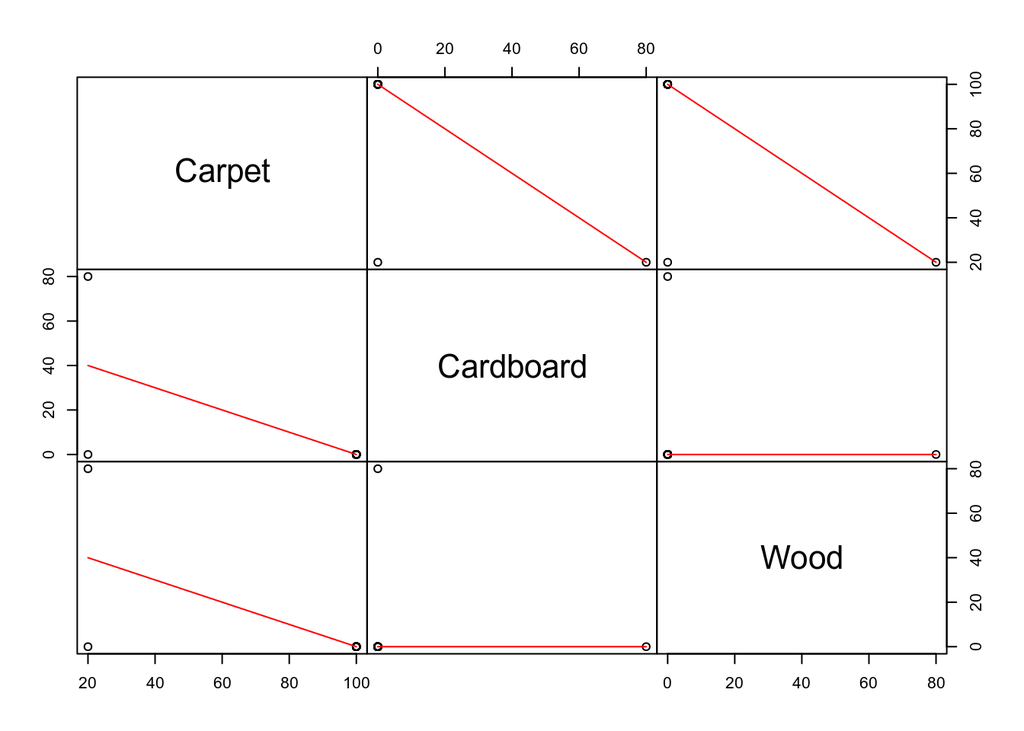

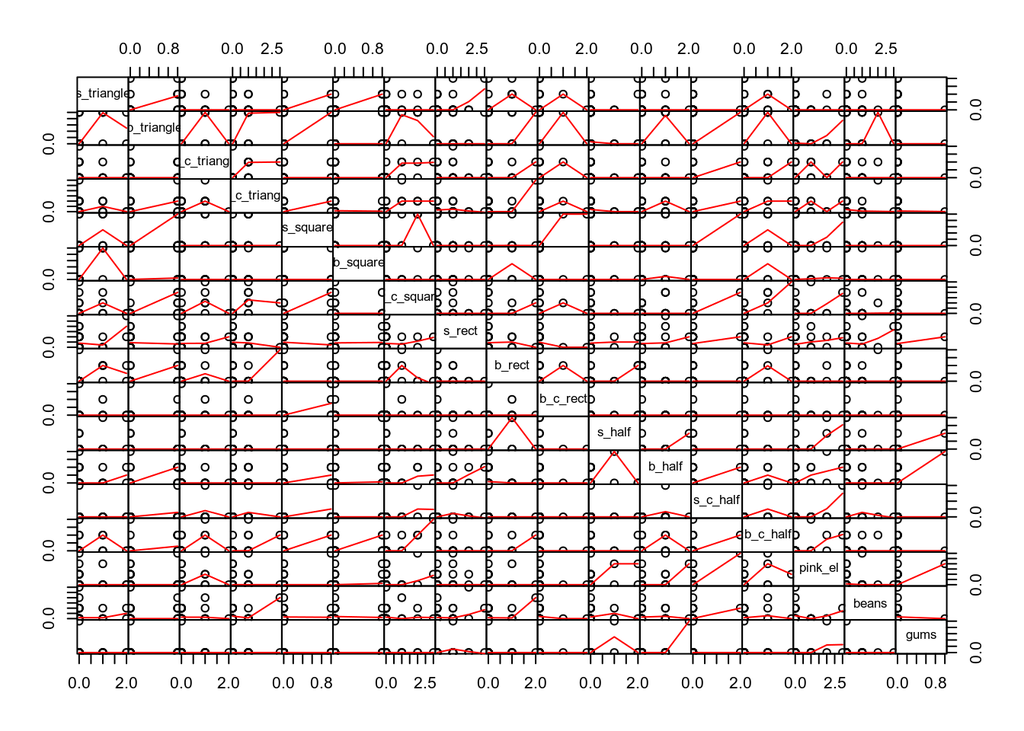

Creating a visual representation of all the points sampled along the transect lines. First i mutate the dataset to create a column with the 28 site numbers sampled.

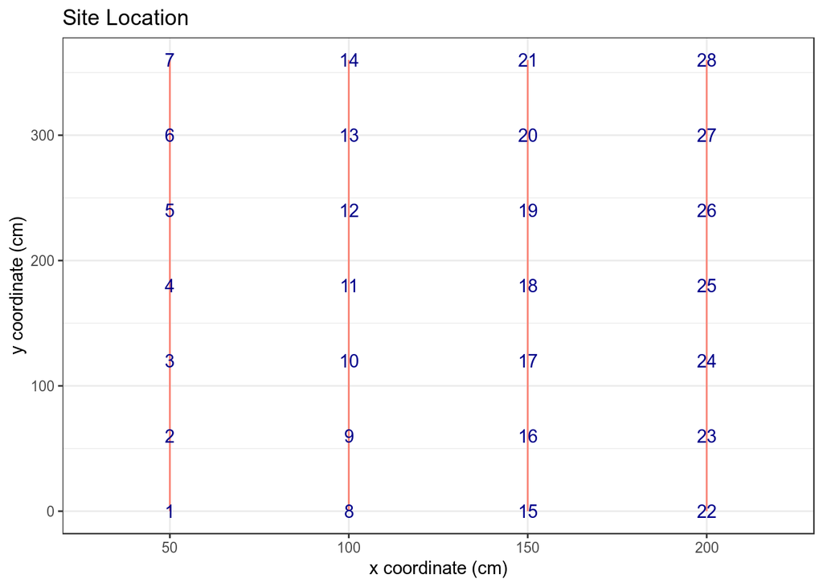

```r
mutated_spa <- spa %>%
  mutate(ID = 1:28) # Adding another column to the dataset

Site_location <- ggplot(mutated_spa, aes(x = as.factor(x), y = as.numeric(y))) +
  geom_path(colour = "salmon") +
  geom_text(aes(label = ID), colour = "blue4") +
  labs(title = "Site Location", x = "x coordinate (cm)", y = "y coordinate (cm)") +
  theme_bw()
Site_location
```

Some more interestong things to do on the species data within the vegan package

```r
diversity(spe, index = "shannon") # diversity analysis quantifying diversity
```

```
R>  [1] 0.0000000 0.0000000 1.0986123 2.0431919 2.3034885 1.7328680 0.6365142
R>  [8] 0.0000000 0.0000000 0.6730117 1.8462202 1.6769878 0.6365142 0.6931472
R> [15] 1.7917595 0.0000000 1.3321790 1.5498260 2.0794415 1.0986123 1.0986123
R> [22] 0.0000000 0.0000000 1.3296613 1.4941751 0.6931472 0.0000000 0.0000000
```

```r
fisher.alpha(spe)
```

```
R>  [1] 1.342178e+08 1.342178e+08 5.368710e+08 3.461453e+01 1.860428e+01
R>  [6] 1.090511e+01 2.622302e+00 1.342178e+08 1.342178e+08 1.235493e+00
R> [11] 8.285589e+00 7.866907e+00 2.622302e+00 2.684355e+08 1.073742e+09
R> [16] 1.000000e+00 9.284141e+00 7.824363e+00 2.147484e+09 5.368710e+08
R> [21] 5.368710e+08 1.342178e+08 1.342178e+08 5.244605e+00 5.705114e+00
R> [26] 2.684355e+08 1.000000e+00 1.000000e+00
```

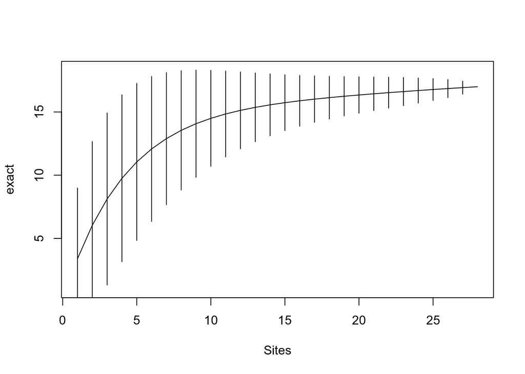

```r
try1 <- specaccum(spe) # calculating species richness within an area
plot(try1) # Plotting the species accumelation curve
```

## Question 1

Here I make use of the dims function within R. This function identifies the number of dimensions of an array or vector. Here i specify the dimensions of the four (species, spatial, environmental and species mass) data sets. The dimensions given as rows x columns.

```r
dim(env)
```

```
R> [1] 28  3
```

```r
dim(spa)
```

```
R> [1] 28  2
```

```r
dim(spe)
```

```
R> [1] 28 17
```

```r
dim(spe_mass) # Dimensions on the species mass dataset
```

```
R> [1] 28 17
```

# Question 2

1. I now create a visualisation on the Cartesian (spatial) coordinates of the species richness, Shannon-Weaver index and the Simpson’s Index. Here I make use of the diversity function allowing me to apply the different index’s to the dataset. I also make use of the annotate function, this functon allows me to indicate the point of dispersal on the graphs created below.

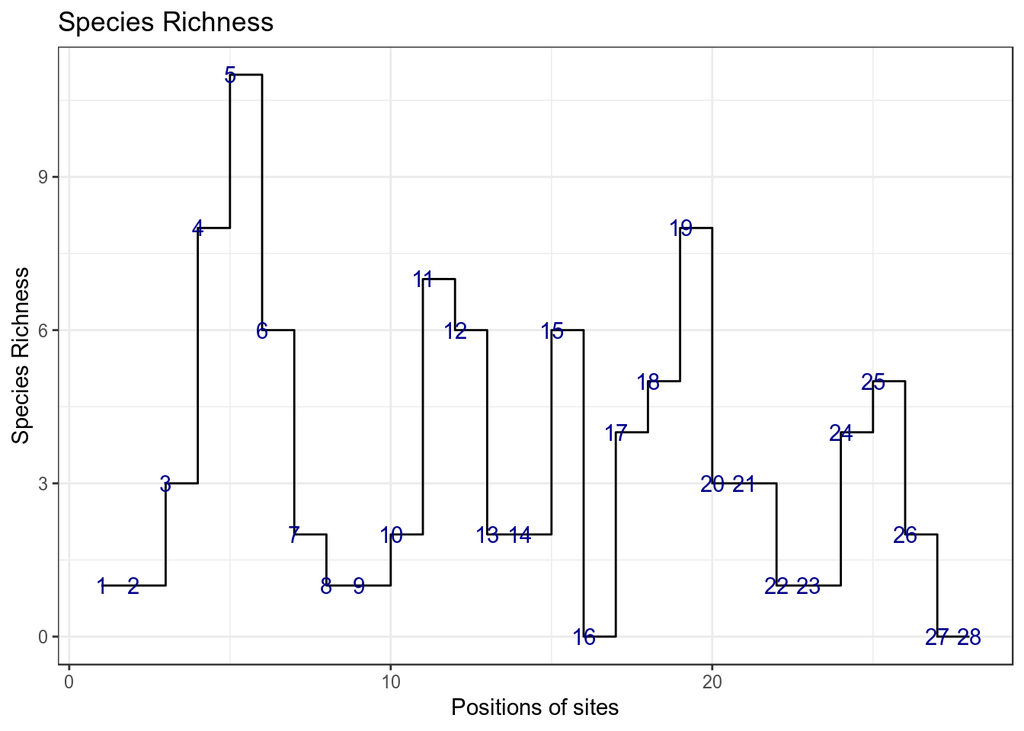

```r
# Compute the number of species at each site
# To sum by rows, the second argument of apply(), MARGIN, is set to 1
# Sort the results in increasing order
# sort_sit.pres <- sort(sit.pres$apply.spe...0..1..sum.)
# sit.pres_df$spe_rich <- as.numeric(sit.pres_df$spe_rich)

sit.pres <- apply(spe > 0, 1, sum)
site_df <- data.frame(spa = sit.pres)
sit.pres_df <- data.frame(spe_richness = sit.pres)

spe_richness <- sit.pres_df %>%
  mutate(ID = 1:28)

plot1 <- ggplot(spe_richness, aes(x = ID, y = spe_richness)) +
  geom_step() +
  geom_text(aes(label = ID), colour = "blue4") +
  labs( x = "Positions of sites", y = "Species Richness",
        title = "Species Richness") +
  theme_bw()
plot1
```

```r
# species richness on spatial dataset
spa_new <- as.numeric(mutated_spa$x) # converting to numeric
spa_updated <- as.numeric(mutated_spa$y) # converting to numeric
spa_new2_dataframe <- data.frame(Y = spa_updated) # formatting into a dataframe
spa_new_dataframe <- data.frame(X = spa_new) # formatting into a dataframe
new_plot <- cbind(spa_new_dataframe,spa_new2_dataframe) # Combining the dataset
add <- new_plot %>%
  mutate(ID = 1:28)

# Plotting species richness
# Here the size of the circles is proportional to the species abuandance
# The bgger the circle the higher the species abundance
# By changing the code to 'show.legend = TRUE' instead of 'show.legend = FALSE', we will be able to see the legend provided which illistrate the values corresponding to the different circle sizes.

plot2 <-  ggplot(add, aes(x = as.factor(X), y = Y)) +
  geom_line(colour = "salmon") +
  geom_point(aes(cex = spe_richness$spe_richness), shape = 1, colour = "blue4", show.legend = FALSE) +
  annotate("text", x = 1, y = 400, label = "1st point of dispersal", size = 2.5) +
  annotate("text", x = 1, y = -30, label = "2nd point of dispersal", size = 2.5) +
  labs(title = "Map of Species Richness", x = "x coordinate (cm)", y = "y coordinate (cm)") +
  theme(legend.position="bottom")
  theme_bw()
```

[output not shown]

[output cut: 342 more lines]

[output not shown]

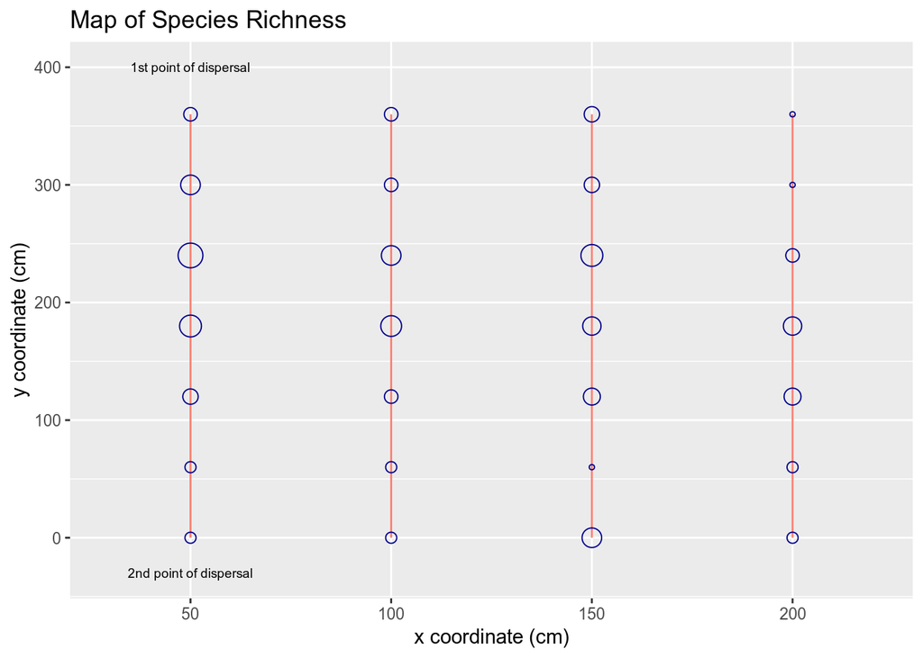

```r
plot2
```

```r
# Shannon-Weaver Plot
# Here the size of the circles is proportional to the species diversity
# The bgger the circle the higher the diversity
# By changing the code to 'show.legend = TRUE' instead of 'show.legend = FALSE', we will be able to see the legend provided which illistrate the values corresponding to the different circle sizes.

Shannon <- as.tibble(diversity(spe, index = "shannon")) # using the diversity function to apply the shannon index
plot3 <- ggplot(mutated_spa, aes(x = as.factor(x), y = as.numeric(y))) +
  geom_path(colour = "salmon") +
  geom_point(aes(cex = Shannon$value), shape = 1, colour = "blue4", show.legend = FALSE) +
    annotate("text", x = 1, y = 400, label = "1st point of dispersal", size = 2.5) +
  annotate("text", x = 1, y = -30, label = "2nd point of dispersal", size = 2.5) +
  labs(title = "Shannon-Weaver Diversity Index ", x = "x coordinate (cm)", y = "y coordinate (cm)")  +
  theme(legend.position="bottom")
  theme_bw()
```

[output not shown]

[output cut: 342 more lines]

[output not shown]

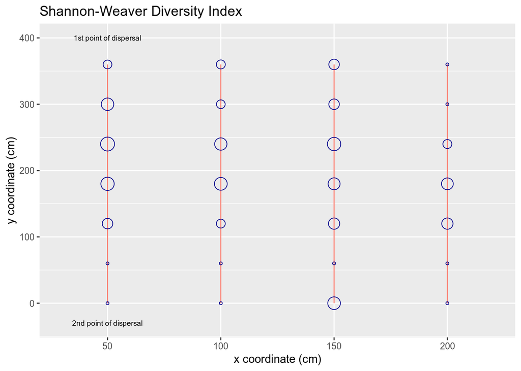

```r
plot3
```

```r
# Simpson's Index Plot
  # Here the size of the circles is proportional to the species diversity
# The bgger the circle the higher the diversity
# By changing the code to 'show.legend = TRUE' instead of 'show.legend = FALSE', we will be able to see the legend provided which illistrate the values corresponding to the different circle sizes.

  simpsons <- as.tibble(diversity(spe, index = "simpson")) # Using the diversity function to apply the simpsons index
plot4 <- ggplot(mutated_spa, aes(x = as.factor(x), y = as.numeric(y))) +
  geom_path(colour = "salmon") +
  geom_point(aes(cex = simpsons$value), shape = 1, colour = "blue4", show.legend = FALSE) +
    annotate("text", x = 1, y = 400, label = "1st point of dispersal", size = 2.5) +
  annotate("text", x = 1, y = -30, label = "2nd point of dispersal", size = 2.5) +
  labs(title = "Simpson Index ", x = "x coordinate (cm)", y = "y coordinate (cm)") +
  # guides(fill=guide_legend(title= "Species abundance")) +
  theme(legend.position="bottom")
  theme_bw()
```

[output not shown]

[output cut: 342 more lines]

[output not shown]

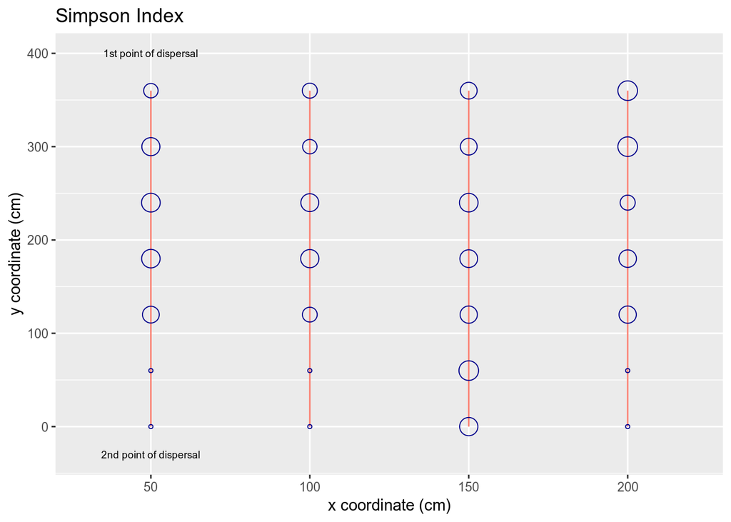

```r
plot4
```

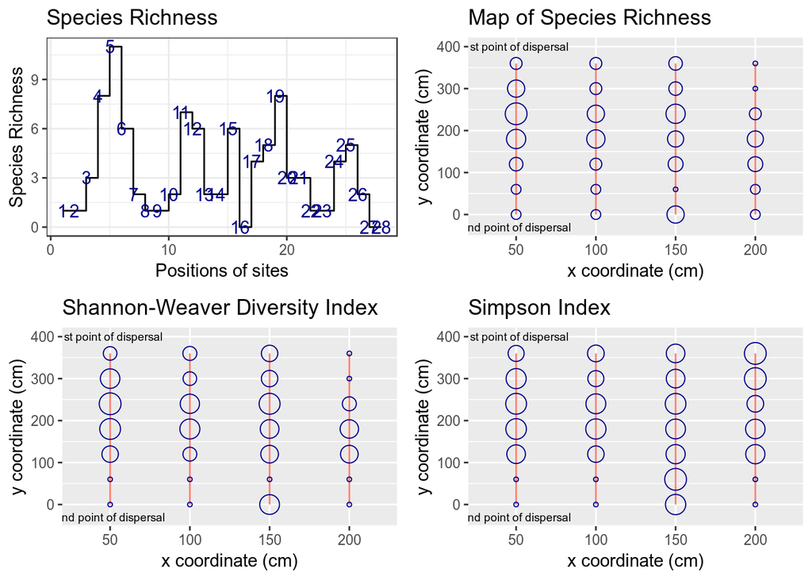

```r
combined_plot <- ggarrange(plot1, plot2, plot3, plot4)
combined_plot
```

ii.

Plot1 Representing species richness and plot 2 representing a map of species richness, focuses on the abundance of each species. The number of different species varied within each quadrat due to the random dispersal of species from two different points in the study area and with wind influencing the dispersal of species. Sites 17 and 18 were unique in that it comprised of wood and a cardboard box with an incline and have an average species richness. Site 5, also being the site of dispersal, had the greatest number of species present. Site 27 and 28 appeared to have no species present. These sites were the furthest from the point of dispersal even with wind acting as a vector, species were unable to disperse at such a great distance. Further into the practical, the position of dispersal changed and the wind vector resulted in a variation in species distribution. Both sites 27 and 28 have the lowest species richness as species were dispersed towards the centre of the study site from their points of dispersal, making it difficult for species to end up at these sites (being in the outskirts of the study area) as well as at other sites bordering the study site.

Plot 3 representing the Shannon weaver index focused on species diversity. - The Shannon index emphasises evenness. The species diversity appeared to be much higher in the middle quadrat of each of the transects. There was a high species diversity at the 1st point of dispersal in contrast to the low species diversity found at the 2nd point of dispersal. The much heavier species (gums and beans) were dispersed at this point and the wind applied did not influence dispersal, however, at the 2nd site of dispersal wind influenced the distribution of the species already colonised after the 1st dispersal. The evidence of high evenness in the central egion of the study site may be attributed to species dispersing from there point of release to the centre of the study. Sites further away from the dispersal point (sites 22,23,27 and 29) express a lower species richness and diversity and as a result a low evenness.

Plot4 (Simpsons Index): The Simpson’s index incorporates species richness and the abundance of relative species. The diversity of species closely correlates to the species richness as seen in the combined plot. The diversity of species is greatest in the central region of the study site, the areas possessing the greatest species richness. The species diversity is low at sites 1 and 2, site 1 being the dispersal point of the gums and jelly species, whereas there is a higher species diversity at sites 6 and 7, site 7 being the release of the paper species. As the gummy and jelly species possess a greater mass, they dispersed further away from their point of release than the paper species, irrespective of the wind. The wind also played a role in further dispersing the colonized paper species through the release of the gummy and jelly species. As species richness and evenness increases, so does the diversity.

## Question 3

1. Below I calculate an association matrix for the species data by first transposing the data. Here I make use of the vegdist function. This function computes dissimilarity indices that are useful for or popular with community ecologists.

```r
#i.
spe.t <- t(spe) # Transposing the datset
spe.t
```

```
R>              [,1] [,2] [,3] [,4] [,5] [,6] [,7] [,8] [,9] [,10] [,11]
R> s_triangle      0    0    0    1    0    1    0    0    0     0     0
R> b_triangle      0    0    0    1    1    0    0    0    0     0     1
R> s_c_triangle    0    0    0    0    1    0    0    0    0     0     1
R> b_c_triangle    0    0    1    1    1    0    0    0    0     0     3
R> s_square        0    0    0    1    1    0    1    0    0     0     0
R> b_square        0    0    0    1    0    1    0    0    0     0     0
R> b_c_square      0    0    1    2    2    0    0    0    0     0     1
R> s_rect          1    0    1    0    1    0    0    0    0     2     0
R> b_rect          0    0    0    0    0    1    0    0    0     0     2
R> b_c_rect        0    0    0    0    0    0    2    0    0     0     0
R> s_half          0    0    0    0    0    2    0    0    0     0     0
R> b_half          0    0    0    1    1    0    0    0    0     0     0
R> s_c_half        0    0    0    0    2    0    0    0    0     0     0
R> b_c_half        0    0    0    1    1    1    0    0    0     0     1
R> pink_el         0    0    0    0    3    2    0    0    0     0     0
R> beans           0    1    0    0    1    0    0    1    1     3     2
R> gums            0    0    0    0    0    0    0    0    0     0     0
R>              [,12] [,13] [,14] [,15] [,16] [,17] [,18] [,19] [,20] [,21]
R> s_triangle       0     0     0     1     0     0     0     1     0     0
R> b_triangle       0     0     0     1     0     0     0     1     1     0
R> s_c_triangle     1     2     0     0     0     0     0     1     0     1
R> b_c_triangle     1     0     0     0     0     0     0     1     1     1
R> s_square         0     0     0     0     0     0     0     1     0     0
R> b_square         0     0     0     1     0     1     0     0     0     0
R> b_c_square       3     0     0     0     0     0     0     1     0     0
R> s_rect           1     1     0     1     0     2     1     0     0     0
R> b_rect           0     0     0     1     0     0     0     1     0     0
R> b_c_rect         0     0     0     0     0     0     0     1     0     0
R> s_half           0     0     0     0     0     0     1     0     0     0
R> b_half           0     0     1     0     0     1     2     0     1     0
R> s_c_half         0     0     0     0     0     0     0     0     0     0
R> b_c_half         2     0     0     0     0     0     0     0     0     0
R> pink_el          1     0     1     0     0     1     2     0     0     1
R> beans            0     0     0     1     0     0     0     0     0     0
R> gums             0     0     0     0     0     0     1     0     0     0
R>              [,22] [,23] [,24] [,25] [,26] [,27] [,28]
R> s_triangle       0     0     2     2     0     0     0
R> b_triangle       0     0     0     1     0     0     0
R> s_c_triangle     0     0     0     0     0     0     0
R> b_c_triangle     0     0     0     0     0     0     0
R> s_square         0     0     0     0     0     0     0
R> b_square         0     1     0     0     0     0     0
R> b_c_square       0     0     0     0     0     0     0
R> s_rect           1     0     1     3     0     0     0
R> b_rect           0     0     1     0     0     0     0
R> b_c_rect         0     0     0     0     0     0     0
R> s_half           0     0     2     0     1     0     0
R> b_half           0     0     0     1     0     0     0
R> s_c_half         0     0     0     0     0     0     0
R> b_c_half         0     0     0     0     0     0     0
R> pink_el          0     0     0     0     0     0     0
R> beans            0     0     0     1     1     0     0
R> gums             0     0     0     0     0     0     0
```

```r
spe.t.S7 <- vegdist(spe.t) #Computing dissimilarity indeces on the transpose data
round(as.matrix(spe.t.S7), 2) # rounding off the value to two decimal places
```

```
R>              s_triangle b_triangle s_c_triangle b_c_triangle s_square
R> s_triangle         0.00       0.47         0.87         0.78     0.67
R> b_triangle         0.47       0.00         0.57         0.41     0.45
R> s_c_triangle       0.87       0.57         0.00         0.41     0.64
R> b_c_triangle       0.78       0.41         0.41         0.00     0.57
R> s_square           0.67       0.45         0.64         0.57     0.00
R> b_square           0.54       0.67         1.00         0.87     0.78
R> b_c_square         0.78       0.53         0.53         0.40     0.57
R> s_rect             0.67       0.74         0.74         0.77     0.90
R> b_rect             0.43       0.54         0.69         0.62     0.80
R> b_c_rect           0.82       0.80         0.80         0.85     0.43
R> s_half             0.57       1.00         1.00         1.00     1.00
R> b_half             0.75       0.47         0.87         0.67     0.67
R> s_c_half           1.00       0.78         0.78         0.83     0.67
R> b_c_half           0.71       0.54         0.54         0.50     0.60
R> pink_el            0.89       0.89         0.67         0.71     0.87
R> beans              0.80       0.58         0.79         0.73     0.88
R> gums               1.00       1.00         1.00         1.00     1.00
R>              b_square b_c_square s_rect b_rect b_c_rect s_half b_half
R> s_triangle       0.54       0.78   0.67   0.43     0.82   0.57   0.75
R> b_triangle       0.67       0.53   0.74   0.54     0.80   1.00   0.47
R> s_c_triangle     1.00       0.53   0.74   0.69     0.80   1.00   0.87
R> b_c_triangle     0.87       0.40   0.77   0.62     0.85   1.00   0.67
R> s_square         0.78       0.57   0.90   0.80     0.43   1.00   0.67
R> b_square         0.00       0.87   0.81   0.64     1.00   0.82   0.69
R> b_c_square       0.87       0.00   0.77   0.75     0.85   1.00   0.78
R> s_rect           0.81       0.77   0.00   0.82     1.00   0.82   0.67
R> b_rect           0.64       0.75   0.82   0.00     0.78   0.67   1.00
R> b_c_rect         1.00       0.85   1.00   0.78     0.00   1.00   1.00
R> s_half           0.82       1.00   0.82   0.67     1.00   0.00   0.86
R> b_half           0.69       0.78   0.67   1.00     1.00   0.86   0.00
R> s_c_half         1.00       0.67   0.89   1.00     1.00   1.00   0.80
R> b_c_half         0.64       0.38   0.82   0.67     1.00   0.83   0.71
R> pink_el          0.75       0.71   0.70   0.88     1.00   0.65   0.47
R> beans            0.88       0.82   0.64   0.67     1.00   0.89   0.80
R> gums             1.00       1.00   0.88   1.00     1.00   0.71   0.78
R>              s_c_half b_c_half pink_el beans gums
R> s_triangle       1.00     0.71    0.89  0.80 1.00
R> b_triangle       0.78     0.54    0.89  0.58 1.00
R> s_c_triangle     0.78     0.54    0.67  0.79 1.00
R> b_c_triangle     0.83     0.50    0.71  0.73 1.00
R> s_square         0.67     0.60    0.87  0.88 1.00
R> b_square         1.00     0.64    0.75  0.88 1.00
R> b_c_square       0.67     0.38    0.71  0.82 1.00
R> s_rect           0.89     0.82    0.70  0.64 0.88
R> b_rect           1.00     0.67    0.88  0.67 1.00
R> b_c_rect         1.00     1.00    1.00  1.00 1.00
R> s_half           1.00     0.83    0.65  0.89 0.71
R> b_half           0.80     0.71    0.47  0.80 0.78
R> s_c_half         0.00     0.75    0.69  0.86 1.00
R> b_c_half         0.75     0.00    0.65  0.78 1.00
R> pink_el          0.69     0.65    0.00  0.91 0.83
R> beans            0.86     0.78    0.91  0.00 1.00
R> gums             1.00     1.00    0.83  1.00 0.00
```

```r
# OR
cor(spe) # func already standardises the dataset
```

```
R>               s_triangle  b_triangle s_c_triangle b_c_triangle    s_square
R> s_triangle    1.00000000  0.42008403  -0.11915865 -0.078007645  0.14852213
R> b_triangle    0.42008403  1.00000000   0.20261022  0.557086015  0.47140452
R> s_c_triangle -0.11915865  0.20261022   1.00000000  0.474059555  0.20057389
R> b_c_triangle -0.07800765  0.55708601   0.47405955  1.000000000  0.24072846
R> s_square      0.14852213  0.47140452   0.20057389  0.240728460  1.00000000
R> b_square      0.24878220  0.16151457  -0.22907152 -0.109972510  0.07613870
R> b_c_square    0.01130828  0.37686733   0.41232874  0.589852555  0.47586687
R> s_rect        0.34607182  0.10629880   0.00000000 -0.187522322 -0.16912036
R> b_rect        0.40684075  0.42107596   0.21499202  0.531704532  0.02977457
R> b_c_rect      0.02119044  0.05044333   0.04292540 -0.009367091  0.64203874
R> s_half        0.46580257 -0.22176638  -0.18871497 -0.205904916 -0.15681251
R> b_half        0.08251230  0.31426968  -0.13371593  0.014589604  0.16666667
R> s_c_half     -0.09335201  0.33333333   0.28365431  0.185695338  0.47140452
R> b_c_half      0.03537746  0.25264558   0.35832004  0.531704532  0.23819653
R> pink_el      -0.08978568  0.02671658   0.20461341  0.074417177  0.18891478
R> beans        -0.03567386  0.22645541   0.00000000  0.199745638 -0.10008010
R> gums         -0.09335201 -0.11111111  -0.09455144 -0.103164077 -0.07856742
R>                 b_square   b_c_square      s_rect      b_rect     b_c_rect
R> s_triangle    0.24878220  0.011308282  0.34607182  0.40684075  0.021190436
R> b_triangle    0.16151457  0.376867331  0.10629880  0.42107596  0.050443327
R> s_c_triangle -0.22907152  0.412328743  0.00000000  0.21499202  0.042925402
R> b_c_triangle -0.10997251  0.589852555 -0.18752232  0.53170453 -0.009367091
R> s_square      0.07613870  0.475866867 -0.16912036  0.02977457  0.642038738
R> b_square      1.00000000  0.026086957  0.01716881  0.17682575 -0.122209985
R> b_c_square    0.02608696  1.000000000  0.01716881  0.08161188 -0.008147332
R> s_rect        0.01716881  0.017168805  1.00000000 -0.13427961 -0.193034347
R> b_rect        0.17682575  0.081611884 -0.13427961  1.00000000  0.063721417
R> b_c_rect     -0.12220999 -0.008147332 -0.19303435  0.06372142  1.000000000
R> s_half        0.15521351 -0.179092509 -0.03536025  0.35484587 -0.100679707
R> b_half        0.10151827  0.101518265  0.30065841 -0.23819653 -0.142675275
R> s_c_half     -0.08973032  0.412759458  0.10629880 -0.08421519 -0.050443327
R> b_c_half      0.17682575  0.843322797 -0.04028388  0.25531915 -0.114698551
R> pink_el       0.12513841  0.306373352  0.10223787 -0.03374913 -0.133419667
R> beans        -0.14630339 -0.018287924  0.26178233  0.24315507 -0.154212717
R> gums         -0.08973032 -0.089730317  0.10629880 -0.08421519 -0.050443327
R>                   s_half      b_half    s_c_half    b_c_half     pink_el
R> s_triangle    0.46580257  0.08251230 -0.09335201  0.03537746 -0.08978568
R> b_triangle   -0.22176638  0.31426968  0.33333333  0.25264558  0.02671658
R> s_c_triangle -0.18871497 -0.13371593  0.28365431  0.35832004  0.20461341
```

[output cut: 17 more lines]

```
R> s_c_triangle  0.00000000 -0.09455144
R> b_c_triangle  0.19974564 -0.10316408
R> s_square     -0.10008010 -0.07856742
R> b_square     -0.14630339 -0.08973032
R> b_c_square   -0.01828792 -0.08973032
R> s_rect        0.26178233  0.10629880
R> b_rect        0.24315507 -0.08421519
R> b_c_rect     -0.15421272 -0.05044333
R> s_half       -0.13810554  0.27104780
R> b_half       -0.13344013  0.62853936
R> s_c_half      0.15097027 -0.03703704
R> b_c_half      0.04290972 -0.08421519
R> pink_el      -0.10890207  0.40074876
R> beans         1.00000000 -0.11322770
R> gums         -0.11322770  1.00000000
```

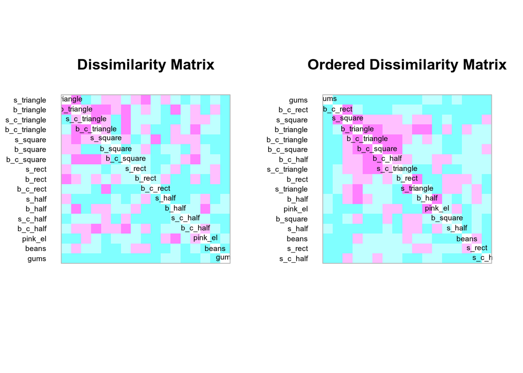

```r
#ii.
coldiss(spe.t.S7, byrank=FALSE, diag=TRUE)
```

Small and big triangles have a dissimilarity of 47% whereas a small and big rectangle have a dissimilarity of 82%. Both crumbled and non crumbled species of the same shape have greater dissimilarities. A small crumbled triangle and a small triangle have a dissimilarity of 87 % and a small crumbled half circle and a small half circle have a dissimilarity of 100%. The crumbled shapes are greatly dissimilar to the gums and have dissimilarities of 1, for example a small crumbled triangle and the gums have a dissimilarity of 1 and a big crumbled square and the gums have a dissimilarity of 1 (minimum similarity).

## Question 4

1. Here i perform a PCA analysis on the species data

```r
# i
spe.pca <- rda(spe, scale=TRUE) # scale = TRUE , mean = 0 , sd = 1
# PCA(rda) - is applied to correlation matrix: Converts it to euclidean space. Low euclidean distance (short plot)
spe.pca
```

```
R> Call: rda(X = spe, scale = TRUE)
R>
R>               Inertia Rank
R> Total              17
R> Unconstrained      17   17
R> Inertia is correlations
R>
R> Eigenvalues for unconstrained axes:
R>   PC1   PC2   PC3   PC4   PC5   PC6   PC7   PC8
R> 3.791 2.475 2.124 1.733 1.573 1.217 1.057 0.898
R> (Showed only 8 of all 17 unconstrained eigenvalues)
```

```r
summary(spe.pca) # Default scaling 2
```

```
R>
R> Call:
R> rda(X = spe, scale = TRUE)
R>
R> Partitioning of correlations:
R>               Inertia Proportion
R> Total              17          1
R> Unconstrained      17          1
R>
R> Eigenvalues, and their contribution to the correlations
R>
R> Importance of components:
R>                         PC1    PC2    PC3    PC4     PC5     PC6     PC7
R> Eigenvalue            3.791 2.4752 2.1244 1.7331 1.57261 1.21742 1.05653
R> Proportion Explained  0.223 0.1456 0.1250 0.1019 0.09251 0.07161 0.06215
R> Cumulative Proportion 0.223 0.3686 0.4936 0.5955 0.68802 0.75963 0.82178
R>                           PC8     PC9    PC10    PC11    PC12     PC13
R> Eigenvalue            0.89815 0.68977 0.59409 0.29194 0.19075 0.153230
R> Proportion Explained  0.05283 0.04057 0.03495 0.01717 0.01122 0.009014
R> Cumulative Proportion 0.87461 0.91519 0.95013 0.96730 0.97853 0.987539
R>                           PC14     PC15     PC16     PC17
R> Eigenvalue            0.084635 0.063794 0.034223 0.029192
R> Proportion Explained  0.004979 0.003753 0.002013 0.001717
R> Cumulative Proportion 0.992517 0.996270 0.998283 1.000000
R>
R> Scaling 2 for species and site scores
R> * Species are scaled proportional to eigenvalues
R> * Sites are unscaled: weighted dispersion equal on all dimensions
R> * General scaling constant of scores:  4.628638
R>
R>
R> Species scores
R>
R>                     PC1      PC2      PC3      PC4      PC5      PC6
R> s_triangle    0.1275428 -0.09235  0.91977 -0.26277  0.25511 -0.07041
R> b_triangle    0.7575715  0.11366  0.36872 -0.11299  0.54400  0.08238
R> s_c_triangle  0.6225770  0.24924 -0.26594  0.22170 -0.16960  0.21966
R> b_c_triangle  0.8307310  0.38317  0.03427  0.25955 -0.09997  0.30889
R> s_square      0.6835497  0.06453 -0.16697 -0.78616  0.20837 -0.01641
R> b_square      0.0721410 -0.18860  0.53051 -0.21405 -0.13135 -0.64755
```

[output cut: 29 more lines]

```
R> sit14 -0.40553 -0.57722 -0.58055 -0.11166 -0.18220  0.04215
R> sit15  0.01061  0.34158  1.67030  0.02934  0.90189 -0.59625
R> sit16 -0.64356  0.28792 -0.47836 -0.04770 -0.29874 -0.16989
R> sit17 -0.36672 -1.06804  0.14231  0.04205  0.50237 -1.29733
R> sit18 -0.29772 -3.18234 -0.25982 -0.11330 -0.39570  2.46928
R> sit19  1.13957  1.21491  0.40354 -1.84852  0.37550  1.19133
R> sit20  0.07055  0.01593 -0.17857 -0.08208  0.56054  0.45010
R> sit21  0.00403  0.29369 -0.72199  0.35158 -0.73282  0.41370
R> sit22 -0.64351  0.12002 -0.37095  0.15479  0.12851 -0.29855
R> sit23 -0.60484  0.13290  0.02969 -0.29897 -0.46867 -1.25203
R> sit24 -0.48117 -0.21754  2.23500 -0.30977 -0.66854  0.57378
R> sit25 -0.05629 -0.66294  1.34266  0.31147  2.68560 -0.19110
R> sit26 -0.65209  0.15375  0.03639  0.24228 -0.45531  0.26503
R> sit27 -0.64356  0.28792 -0.47836 -0.04770 -0.29874 -0.16989
R> sit28 -0.64356  0.28792 -0.47836 -0.04770 -0.29874 -0.16989
```

```r
# summary(spep.pca, scaling=1)

(spe <- spe.pca$CA$eig) # Eigenvalues
```

```
R>        PC1        PC2        PC3        PC4        PC5        PC6
R> 3.79092323 2.47519898 2.12441329 1.73313687 1.57260767 1.21742416
R>        PC7        PC8        PC9       PC10       PC11       PC12
R> 1.05652950 0.89815220 0.68977217 0.59408590 0.29193555 0.19074792
R>       PC13       PC14       PC15       PC16       PC17
R> 0.15323021 0.08463455 0.06379354 0.03422267 0.02919158
```

PCA is one of the many ways to analyse the structure of a given correlation matrix. By construction, the first principal axis is the one which maximizes the variance (reflected by its eigenvalue) when data are projected onto a line and the second one is orthogonal to it, and still maximizes the remaining variance. This is the reason why using the first two axes should yield the better approximation of the original variables space. From the summary, we can undersand PC1 explains 22% of variance and PC2 explains 14% and so on. Usually Principal components which explains about 95% variance can be considered for models. Summary also yields cumulative proportion of the principal components. PCA is eigenvector based. Eigenvalue decomposition reduces complex data to the new variable that captures variability. The eigenvalues tell you how much of the original variance is captured in the direction of the corresponding eigenvector. That tells you how important each eigenvector is. The eigenvalues tell you how much of the original variance is captured in the direction of the corresponding eigenvector. Larger eigenvalue means more important, PC1 largest eigenvalue of 3.791. Thus the first axis has the most explanitory power. Furthur looking at the eigenvalues, the first few values are clearly larger than the following ones. The proportion of variance explained by the first r principal components provides the most variance for any r components. The percentage of variance explained by the first r principal components is just the total variance in the first r principal components divided by the total variance in all n principal components, PC1 proportion explained value is 0.223. PC1 represents the relationship between the new value and the old value. The bigger the values the more important the variance. The high value makes us confident that our interpertation of the first pair of axes extracts the most relevant infomation from the data. The total inertia is the sum of the diagonal of the correlation matrix that feeds into the PCA the sum of the eigenvalues. Only 22% varience is explained by PC1: PC1 is calculated by taking the eigenvalue/total inertia*100. Cummelative propoportion: from PC1-PC6 only explains 75.96% varience. The eigenvalues indicate the importance of the PC axes, with the first PC axis always having the highest eigenvalue, diminishing until the smallest one is found for the last PC axis; the sum of all the eigenvalues equals the total inertia. Eigenvectors: The eigenvectors represent the ‘loadings’ of the original, untransformed species variables on the corresponding eigenvalue (PC axis); they indicate the importance of the original variable along the new reduced dimension captured by the PC axes. Site scores: The coordinates of the sites (rows) on the ordination (Euclidian) space, i.e. the ordination diagram. Species scores: coordinate the arrow heads of variables. The species scores refer to the position of the arrow heads on the PCA biplot; they indicate the direction and relative magnitude of species associated with as a linear gradient across the ‘landscape’, i.e. the reduced space represented by the corresponding PC axes. Site scores: The coordinates of the sites (rows) on the ordination (Euclidian) space, i.e. the ordination diagram. Site scores: Coordinates of the sites in the ordination diagram.

The code below proves the discription above and illistrates how many axes must be retained, and why..

```r
(p1 <- spe.pca$CA$eig[1] / sum(spe.pca$CA$eig)) # For the first PC axis, the proportion of variation explained is given by
```

```
R>       PC1
R> 0.2229955
```

```r
(p2 <- spe.pca$CA$eig[2] / sum(spe.pca$CA$eig))
```

```
R>       PC2
R> 0.1455999
```

```r
(p3 <- spe.pca$CA$eig[3] / sum(spe.pca$CA$eig))
```

```
R>       PC3
R> 0.1249655
```

```r
(p4 <- spe.pca$CA$eig[4] / sum(spe.pca$CA$eig))
```

```
R>       PC4
R> 0.1019492
```

```r
(p5 <- spe.pca$CA$eig[5] / sum(spe.pca$CA$eig))
```

```
R>        PC5
R> 0.09250633
```

```r
(p6 <- spe.pca$CA$eig[6] / sum(spe.pca$CA$eig))
```

```
R>        PC6
R> 0.07161319
```

```r
((p1 + p2 + p3 + p4 + p5 + p6) * 100) # The cumulative inertia (%) of the first six axes is
```

```
R>      PC1
R> 75.96297
```

```r
# 6 of the axes must be retained because the fix six add up to 75% or the first 7 axes because their means are above the average of all of the axes.
```

The eigenvalues sum up to equal the total interia (i.e., total variance in this case). This is evident in the summarry above

```r
sum(spe.pca$CA$eig)
```

```
R> [1] 17
```

The code below lets us plot the PCA calculated above.

```r
# ii
par(mfrow = c(2, 2))
biplot(spe.pca, scaling = 1, main = "PCA - scaling 1 (sites)")
biplot(spe.pca, main = "PCA - scaling 2 ('species')") # default scaling 2
cleanplot.pca(spe.pca, scaling = 1, mar.percent = 0.08) # sites scaling
```

```
R> circle2 = TRUE
```

```
R> circle2 = TRUE
```

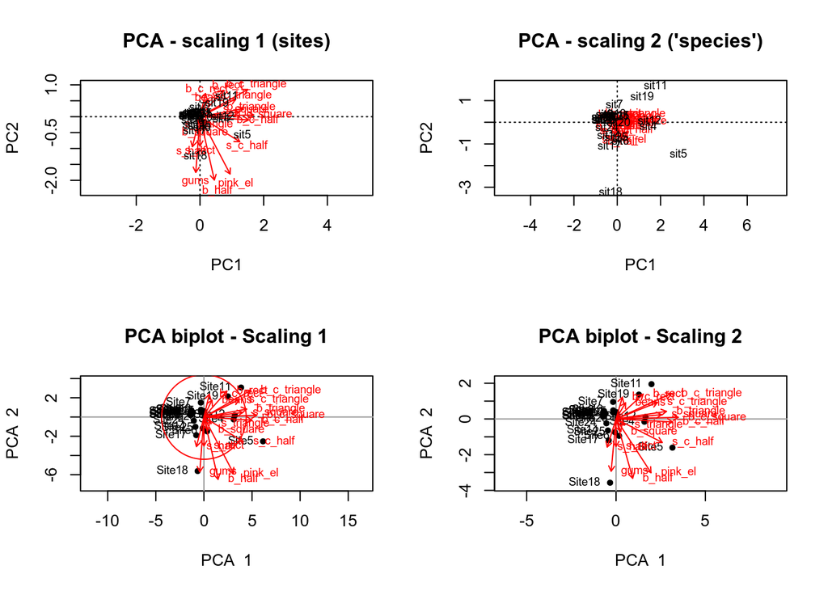

```r
cleanplot.pca(spe.pca, scaling = 2, mar.percent = 0.04)
```

ii.

The scaling 1biplot: The distances between object points approximate the Euclidean distances between objects. Thus, objects ordinated closer together can be expected to have similar variable values. Right-angled projections of an object point on a variable’s vector approximates the value of that variable for the chosen object. The length of a variable vector in the ordination plot reflects its contribution to the ordination. The scaling 1 biplot shows a gradient from left to right, starting with a group formed by sites 6, 14, 17, 24, 25 which display the highest values of small half rectangle and gums, as you move to the other sites the number of these species decreases, and the lowest values for all of the other shapes. All the sites in the top left quadrant appear to have the lowest values for all of the different species and are not associated with either of the species. A third group of very similar sites (11, 12 and 19) show high values for a range of different species regardless of the size and type of species present, these sites however appear to have the lowest values for the gummy species present. The big crumbled half circle and small crumbled half circle, as well as the big square show their maximum values around sites 4 and 5; the values decrease afterwards. There are also a range of other shapes within this region that are correlated to both of these sites.

Scaling 2bioplot: The angles between all vectors approximate their (linear) covariance/correlation. The scaling 2 biplot shows that the variables are organized in groups with no variables laying within the top left quadrant of the plot (no species present at those sites). The lower left part of the biplot shows that small half circles and gums are very highly, positively correlated, and that these two variables are very highly, negatively correlated with another group comprising of all the variables on the top right side of the plot. The top right portion of the plot shows all the variables (Species) that are highly correlated with each other. Variables (species) on the top right portion of the plot is highly correlated with variables (species) on the bottom right of the plot. Many of the species distribution on the right portion of the plot can also be looked as orthogonal arrows, indicating a correlation close to 0. An example of this is evident when looking at big half circles and big crumbled squares/ big crumbled half circles, similarly this could be applied to many of the other species. Small half circles, big square and small triangle, displays a shorter arrow, showing its lesser importance for the ordination of the sites in the ordination plane. This example shows how useful a biplot representation can be in summarizing the main features of a data set (clusters of different species at sites are obvious). Right-angled projections of an object point on a variable’s vector approximates the value of that variable for the chosen object. Distances between object points may be non-Euclidean and should not be interpreted with great confidence.

## Question 5

1. Below is the code needed to for undertaking an NMDS analysis onthe species data. Here we make use of the metaMDS function within the vegan package. Before running this analysis we are required to remove all the rows that contain only zero values.

```r
spe <- read_csv("Data/spe.csv") # at times the species data need to be reloaded- dataset format changed above so reload
spe.1 <- spe[-16,]
remove_spe <- spe.1[-26:-27,]
spe.d <- vegdist(remove_spe, method = "bray", binary = TRUE)
```

```r
# If it doesnt load properly reload the species dataset
# Removing the rows with no data for this analysis

# spe_metaMDS <- metaMDS(spe.d)
# spe_metaMDS
#
# dev.new(title="NMDS on species - Percentage difference")
# plot(spe_metaMDS, type = "t", main = paste("NMDS/Percentage difference", round(spe_metaMDS$stress, 3)))
#
# par(mfrow = c(2, 2))
# stressplot(spe_metaMDS, spe.d)
# ordiplot(spe_metaMDS, type = "t", display = c("sites"),
#          main = "NMDS with site scores")
# abline(v = 0, h = 0, lty = 3)
#
# dev.new(title="NMDS - Shepard plot", width=12, height=6)
# par(mfrow=c(1,2))
# stressplot(spe_metaMDS, main="Shepard plot")
# gof <- goodness(spe_metaMDS)
# plot(spe_metaMDS, type="t", main="Goodness of fit")
# points(spe_metaMDS, display="sites", cex=gof*300)
```

```r
###################### According to the book.........

spe.nmds <- metaMDS(remove_spe, distance="bray")
```

```
R> Run 0 stress 0.1369755
R> Run 1 stress 0.136107
R> ... New best solution
R> ... Procrustes: rmse 0.1147465  max resid 0.2695905
R> Run 2 stress 0.143498
R> Run 3 stress 0.1370774
R> Run 4 stress 0.138019
R> Run 5 stress 0.1354654
R> ... New best solution
R> ... Procrustes: rmse 0.03410667  max resid 0.1423477
R> Run 6 stress 0.1492349
R> Run 7 stress 0.138804
R> Run 8 stress 0.1401699
R> Run 9 stress 0.1378712
R> Run 10 stress 0.1400439
R> Run 11 stress 0.1490536
R> Run 12 stress 0.1388068
R> Run 13 stress 0.1383878
R> Run 14 stress 0.1354652
R> ... New best solution
R> ... Procrustes: rmse 0.0002063607  max resid 0.0004211836
R> ... Similar to previous best
R> Run 15 stress 0.1400891
R> Run 16 stress 0.1378588
R> Run 17 stress 0.1451261
R> Run 18 stress 0.1390449
R> Run 19 stress 0.1401703
R> Run 20 stress 0.1369668
R> *** Solution reached
```

```r
spe.nmds
```

```
R>
R> Call:
R> metaMDS(comm = remove_spe, distance = "bray")
R>
R> global Multidimensional Scaling using monoMDS
R>
R> Data:     remove_spe
R> Distance: bray
R>
R> Dimensions: 2
R> Stress:     0.1354652
R> Stress type 1, weak ties
R> Two convergent solutions found after 20 tries
R> Scaling: centring, PC rotation, halfchange scaling
R> Species: expanded scores based on 'remove_spe'
```

```r
spe.nmds$stress
```

```
R> [1] 0.1354652
```

```r
dev.new(title="NMDS on the different species - Percentage difference")
plot(spe.nmds, type="t", main=paste("NMDS/Percentage difference - Stress =", round(spe.nmds$stress,3)))

# Shepard plot and goodness of fit
dev.new(title="NMDS - Shepard plot", width=12, height=6)
par(mfrow=c(1,2))
stressplot(spe.nmds, main="Shepard plot")
gof <- goodness(spe.nmds)
plot(spe.nmds, type="t", main="Goodness of fit")
points(spe.nmds, display="sites", cex=gof*300)
```

[output not shown]